# **Аннотации статей российских социологов: промежуточные результаты**

Arthur Pecherskih (*last updated on* 23.05.23)

## **Описание данных**

название журнала

статей в РИНЦ

статей собрано

год основания

собранный период

статей с аннотациями

Социологические исследования

6778

2524

1974

2014—2023

1588

Социология власти

2117

1897

1989

2003—2022

915

Мониторинг общественного мнения: экономические и социальные перемены

2704

1697

1993

1993—2022

1184

Вестник ТГУ. Философия. Социология. Политология

1674

1666

2007

2007—2022

1589

Журнал социологии и социальной антропологии

1650

1650

1998

1998—2022

1420

Социологический журнал

1529

1590

1994

1994—2022

518

Экономическая социология

1291

1285

2000

2000—2023

481

Вестник РУДН. Серия: социология

1101

1039

2001

2001—2022

658

Журнал исследований социальной политики

976

939

2003

2003—2022

661

Мир России. Социология. Этнология

895

882

1992

1992—2023

816

Социологическое обозрение

848

862

2001

2001—2022

659

Женщина в российском обществе

815

856

1996

1996—2022

659

Laboratorium

840

712

2009

2009—2022

454

Вестник института социологии

515

494

2010

2010—2022

416

Социологическая наука и социальная практика

433

454

2013

2013—2022

368

Социология. 4М

196

431

1991. 2007

1991—2021

367

Демографическое обозрение

303

303

2014

2014—2022

235

Вестник СПбГУ. Социология

187

278

2008. 2016

2015—2022

235

Хотя основным материалом для дальнейшего анализа стали тексты аннотаций, стоит заметить, что различия в тематических/методологических журнальных ориентациях обнаруживается и при сравнении наиболее частотных ключевых слов (см. таблицу ниже). Стоит отметить, что два журнала, *“Социологическое обозрение”* и *“Вестник ТГУ”*, отличаются от прочих наличием высокочастотных ключевых слов, отсылающих к конкретным людям, в том числе не относящихся к социологическому дисциплинарному канону (н. Ханна Арендт в списке для *“СоцОбоза”*). Журналы, посвященные более узким темам, вроде *“Демографического обозрения”* или *“Экономической социологии”*, также показывают свое отличие на уровне ключевых слов. Здесь же стоит обратить внимание на довольно низкий порядок частотностей (относительно числа журнальных статей), который может свидетельствовать как о (1) разнообразии тем, поднятых в статьях, так и о (2) том, что сами журналы (члены их редколлегий) не стремятся сделать из указания ключевых слов институированную практику, заранее ограничивающую их выбор.

| название журнала (число указанных ключевых слов всего) | наиболее частотные ключевые слова |
| --- | --- |
| Социологические исследования (5835) | молодежь (49), россия (42), социология (40), ценности (38), миграция (36), семья (33), гражданское общество (31), модернизация (30), образование (29), рынок труда (27) |
| Социология власти (3689) | государство (27), глобализация (22), акторно-сетевая теория (20), модернизация (17), гражданское общество (16), власть (15), культура (15), управление (14), безопасность (12), государственное управлен… |
| Мониторинг общественного мнения (4662) | молодежь (71), социальные сети (34), выборы (31), интернет (29), миграция (26), образование (24), общественное мнение (24), рынок труда (24), ценности (23), россия (20), социальные медиа (20) |
| Вестник ТГУ. Философия. Социология. Политология (4672) | наука (32), коммуникация (30), культура (28), онтология (27), семантика (27), витгенштейн (26), значение (25), язык (25), истина (24), эпистемология (24) |
| Журнал социологии и социальной антропологии (3978) | россия (47), глобализация (32), история социологии (21), модернизация (21), общество потребления (21), потребление (21), идентичность (20), а.с. лаппо-данилевский (17), молодежь (17), социология (17) |
| Социологический журнал (2448) | социология (17), история социологии (15), россия (12), общественное мнение (11), ценности (11), образование (9), п.а. сорокин (9), рынок труда (9), социальный капитал (9), доверие (8), идеология (8), … |
| Экономическая социология (1726) | институты (20), государство (19), рынок (16), рынок труда (16), капитализм (14), доверие (13), потребление (13), экономический рост (12), занятость (10), социальное неравенство (10), социальные сети (… |
| Вестник РУДН (3019) | молодежь (44), ценностные ориентации (19), глобализация (18), идентичность (18), информационное общество (15), ценности (15), студенты (14), власть (13), рынок труда (13), культура (12), социальные се… |
| Журнал исследований социальной политики (1946) | социальная политика (42), инвалидность (29), россия (23), социальная работа (20), гендер (17), инклюзия (17), миграция (15), бедность (12), молодежь (12), дискурс (11), нко (11), семья (11), социально… |
| Мир России. Социология. Этнология (2546) | россия (33), социальная структура (23), модернизация (22), рынок труда (18), социальное неравенство (17), неравенство (15), социальная политика (15), социальная стратификация (14), бедность (12), демо… |
| Социологическое обозрение (2588) | макс вебер (36), государство (22), карл шмитт (22), культурсоциология (22), власть (21), этнометодология (20), действие (19), демократия (19), война (18), ханна арендт (18) |
| Женщина в российском обществе (1908) | гендер (57), гендерное равенство (29), гендерные стереотипы (23), женщины (22), семья (15), гендерное неравенство (14), женское движение. (14), россия (14), женщина (11), феминизм (10) |
| Laboratorium (1371) | россия (38), ссср (14), соседство (12), украина (12), гендер (11), миграция (10), историческая память (9), постсоциализм (8), гулаг (7), материальность (7), медиа (7) |
| Вестник института социологии (1860) | молодежь (31), социология (23), ценности (22), образование (16), гражданское общество (15), модернизация (15), россия (13), человеческий капитал (13), культура (12), рынок труда (11) |
| Социологическая наука и социальная практика (1653) | молодежь (17), социальное самочувствие (15), образование (14), ценности (14), адаптация (12), доверие (10), миграция (10), глобализация (9), модернизация (9), занятость (8), идентичность (8), интеграц… |
| Социология. 4М (1941) | кластерный анализ (10), качественные методы (9), измерение (8), контент-анализ (8), семантический дифференциал (8), типологический анализ (8), классификация (7), методология (7), открытые вопросы (7),… |
| Демографическое обозрение (948) | рождаемость (42), смертность (34), россия (27), миграция (19), демографический переход (16), причины смерти (15), продолжительность жизни (10), внешние причины смерти (8), ожидаемая продолжительность … |
| Вестник СПбГУ. Социология (1205) | доверие (5), социология (5), цифровизация (5), гражданское общество (4), контент-анализ (4), национальная идентичность (4), социальные медиа (4), социальный капитал (4) |

## **Результаты - 1: *Wordfish model***

Модель wordfish изначально была разработана для автоматического атрибутирования политических взглядов (левых/правых, авторитарный/либертарный) человека или организации, стоящих за определенным текстом (Slapin and Proksch, 2008). В ее основе находится предположение о пуассоновском распределении частотностей слов в корпусе текстов, позволяющее сконструировать для последнего одномерную шкалу. Согласно недавнему предположению немецких исследователей, эта же модель способна уловить “polar opposition between qualitative work versus quantitative work associated with different schools of thought” (Schwemmer & Wieczorek, 2020, p. 10). При выборе модели авторы отталкивались от необходимости получить веса не только на уровне слов, но и на уровне документов. Подобные оценки могут быть также получены с помощью различных подходов к моделированию тем (н. probabilistic topic models или structural topic models), однако они требуют априорного решения о количестве извлекаемых измерений, усложняя стоящую перед исследователем задачу (*ibid*). В следующем разделе один из этих методов, correlated topic models, используются для получения иной по форме картины того, что происходит в собранном корпусе.

Помимо выбора корректного набора текстовых данных, залогом успеха в корпусной лингвистике является их корректная предобработка. При выборе тех или иных шагов по предобработке корпуса я ориентировался на действия оригинальное исследование немецких авторов (Schwemmer & Wieczorek, 2020, p. 9) с поправкой на специфику русского языка. Итак, в первую очередь из аннотационного корпуса были удалены аннотации, относящиеся к таким публикационным жанрам, как рецензия, круглый стол, перевод, сообщение о семинаре и т. п. Далее, из текстов была удалена не относящаяся к аннотации информация: например, к ней относились ключевые слова, DOI и англоязычная версия аннотации. Здесь же из корпуса были удалены слишком длинные и слишком короткие аннотации. Следующим классическим шагом стала лемматизация текстов с помощью программы *mystem* (Segalovich, 2003). Лемматизация приводит каждое слово к его основе (н. “социологию” -> “социология”, “выделяет” -> “выделять”), анализируя в том числе контекст его употребления, что позволяет провести контекстное снятие омонимии (ситуация, когда обладающие одинаковым звучанием и написанием слова обладают разным значением). Следующим шагом стал поиск коллокаций, - устойчивых в употреблении языковых конструкций (н. “культурный капитал”, “регрессионный анализ”). Их уточнение должно серьезно повышать качество модели: конечно, семантическая разница между аргументами “культурный капитал” и “культурный”/“капитал” велика, и отсутствие этого шага затруднило бы атрибуцию гипотетической статьи, в которой обсуждался бы именно “культурный капитал”. Заключительными шагами после приведения корпуса к виду “мешка слов” (*bag-of-words*, формат, не учитывающий порядок слов и грамматику, при этом сохраняющий информацию о частотности слов) стала нормализация написаний (устранена разница в словах с “ё” и “е”), удаление стоп-слов (слов, не несущих самостоятельной смысловой нагрузки, н. предлоги) и очень редких слов, встречающихся менее чем в 50 аннотациях (проверка других порогов не выявила серьезных различий в результатах).

Как уже было отмечено, состав корпуса не менее важен, чем шаги по его подготовке к анализу. Поскольку модель Wordfish конструирует лишь одно измерение, то лексика, характерная для какой-либо узкой темы, будет неизбежно задавать “тон” всей шкале. Источником таких искажений в результатах является включение в исходную выборку журналов, в чьем фокусе находятся относительно редкие темы, не представленные в прочих изданиях. Для наглядности, ниже последовательно представлены характеристики нескольких моделей, для каждой из которых соблюдался описанный выше порядок предобработки, но различался входной корпус текстов. Первым я предлагаю взглянуть на результаты модели, которая в качестве входных данных получила 2,829 параметров (токенов) 12,075 аннотаций (605,308 слов суммарно).

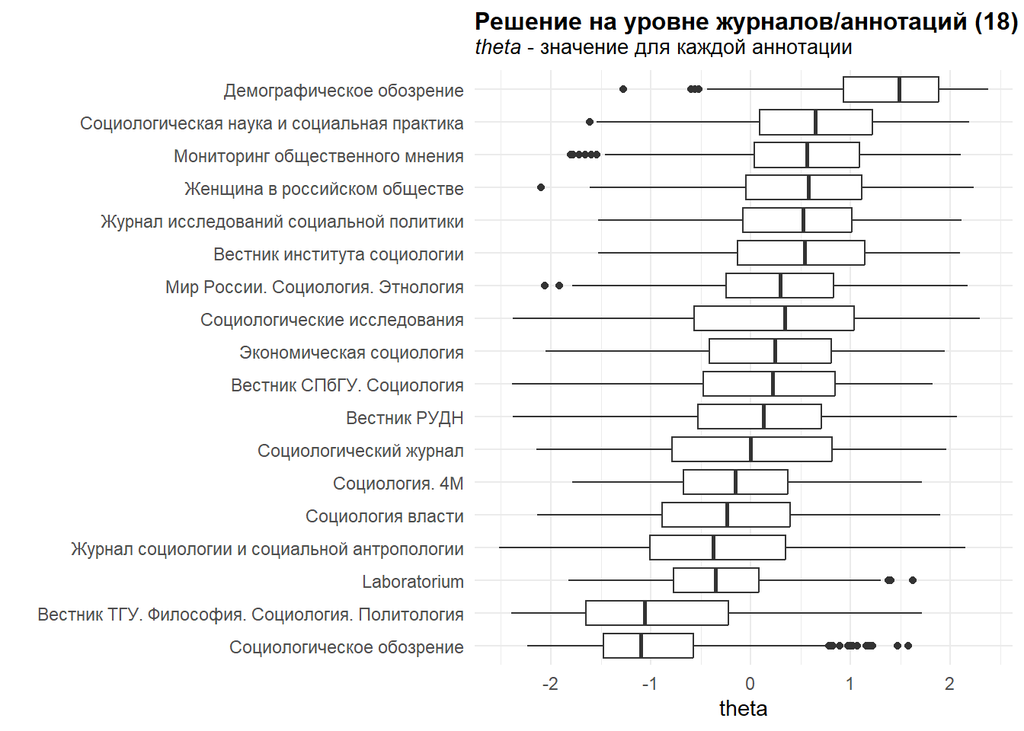

Предложенное на графике выше распределение показывает, что журналы *“Демографическое обозрение”*, *“Вестник ТГУ”* и *“Социологическое обозрение”*, занимающие полярные позиции, сильно отличаются от прочих журналов по используемой лексике. При этом характерно, что сходство последних двух изданий было замечено еще в отношении ключевых слов, - это журналы, в которых часто предметом обсуждения становится история социологии и социологическая теория (*“Вестник”*, как становится ясно из названия, публикует статьи не только по социологии, но и по философии и политологии). Задаваемое этими тремя журналами шкалирование всех прочих журналов не имеет смысла, т.к. ранжирует их публикации от “теоретического” полюса к “демографическому”, - такой континуум в дисциплине точно не наблюдается.

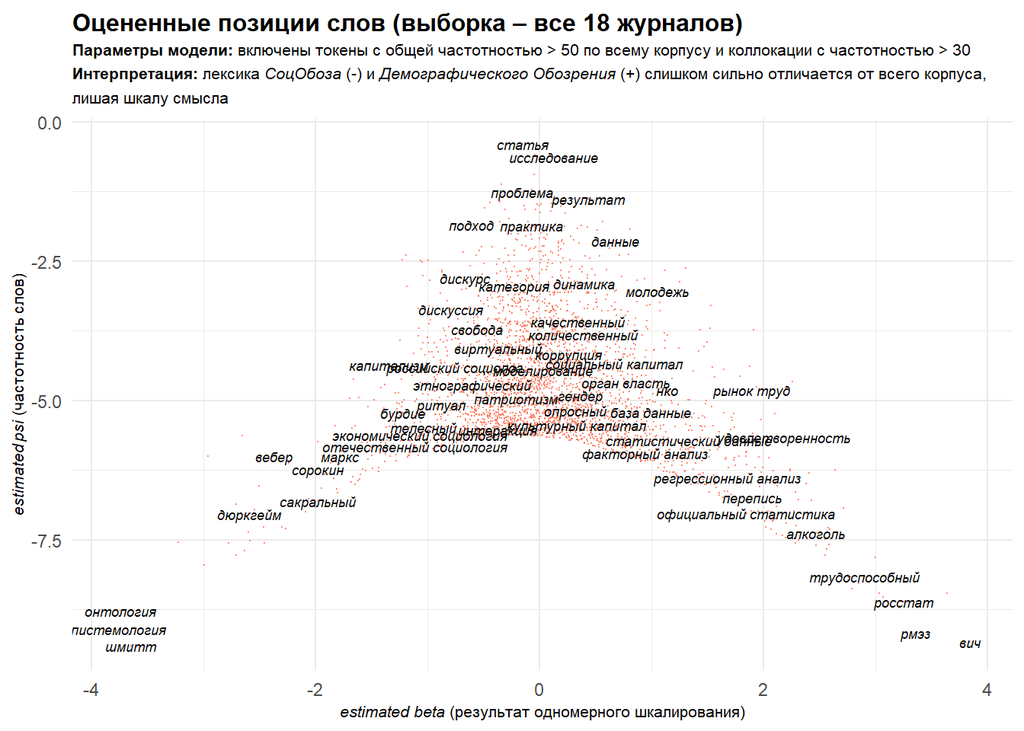

В последующих моделях я последовательно исключал из входных данных те журналы, которые оказывались обладателями исключительно нехарактерной для прочих журналов лексики. Так, ниже представлены модели с 15 (без *“СоцОбоза”*, *“Вестника ТГУ”* и *“Демографического обозрения”*; 9,828 аннотаций при 2,759 токенах) и 14 журналами (в дополнение к прошлому, без журнала *“Женщина в российском обществе”*; 9,184 аннотации при 1,452 токенах).

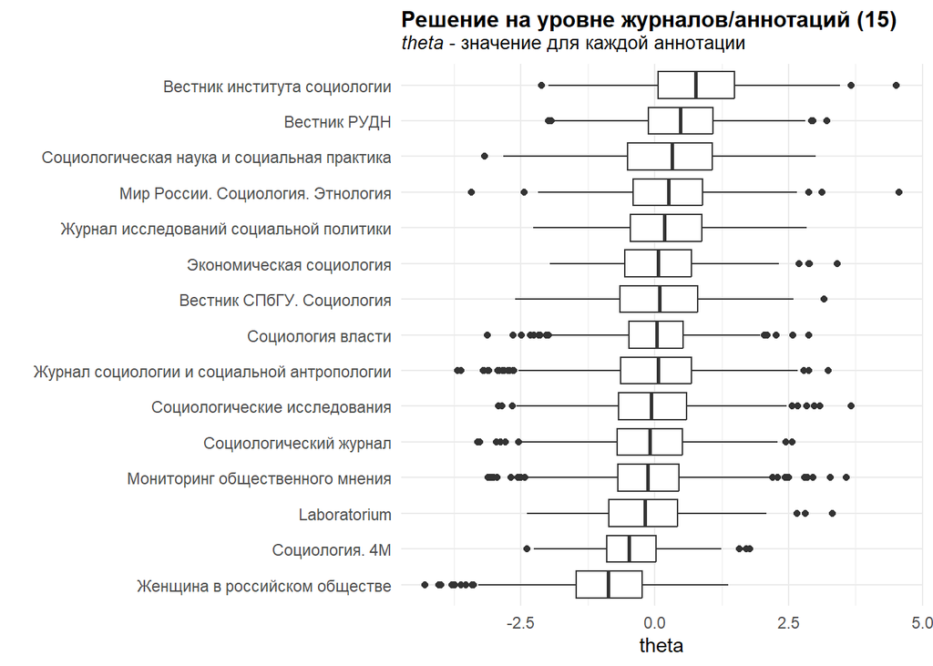

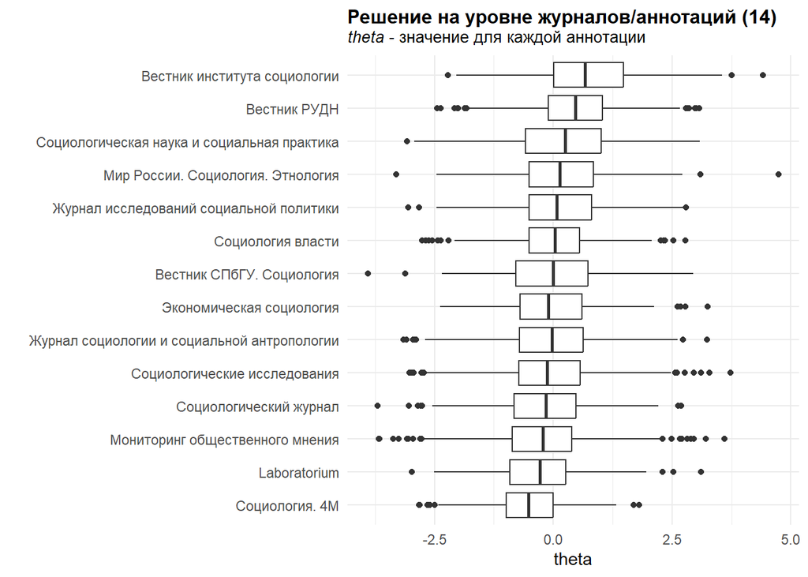

Оба эти решения также не улавливают предполагаемую оппозицию качественного/количественного (качественный *“Laboratorium”* и количественный *“Социология. 4М”* оказались не только рядом, но и на конце шкалы в обоих случаях). Примечательно, что исключение ивановского журнала *“Женщина в российском обществе”* слабо отразилась на положении прочих журналов - можно предположить, что, в отличие от трех исключенных ранее журналов, это издание не исчерпывающе объясняет возникающую шкалу.

Дальнейшие эксперименты с составом входных данных (дальнейшее исключение журналов, фильтрация выпусков по годам выпуска и проч.) не дали более интерпретируемых результатов. В связи с этим была предпринята попытка сконструировать модель, в которой частотности слов сгруппированы не для отдельных статей, но для журналов целиком. Это отчасти обесценивает интенцию, с которой модель применялась для шкалирования аннотаций раньше: получить оценку как документов (аннотаций), так и их источников - журналов (Schwemmer & Wieczorek, 2020, pp. 9-10). Главный минус такого решения - невозможность вернуться с имеющимися весами к метаданным статей для того, чтобы попробовать объяснить вариацию в них с помощью формальных характеристик (н. аффилиации автора). Тем не менее, и такое решение имеет ценность, т. к. дает представление о распределении журнальных корпусов по полученной шкале.

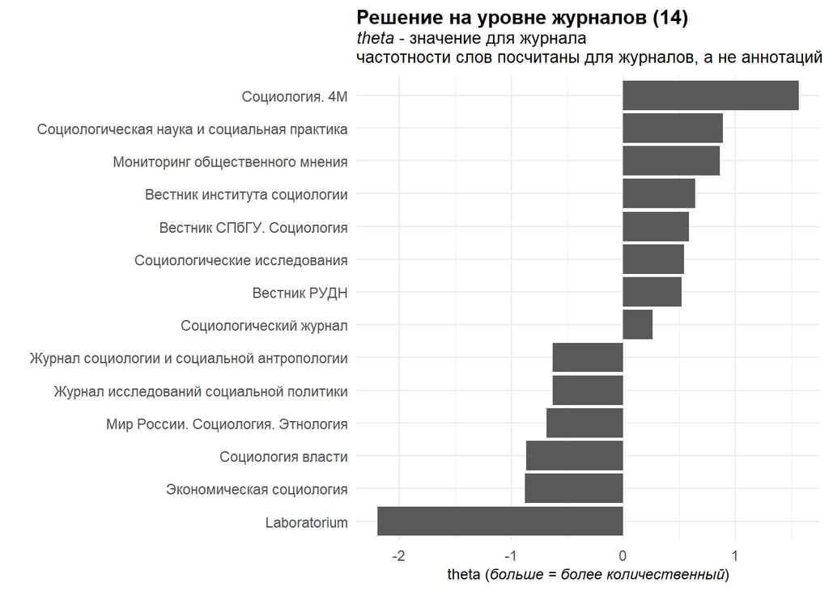

Полученное таким образом распределение поддается удобной интерпретации, т. к. качественный и количественный журналы, *Laboratorium* (согласно описанию журнала на его сайте, у него нет “строгих ограничений” касательно присылаемых материалов, однако одно из его направлений включает именно [“качественные методы социальных исследований (методологическая дискуссия, методологические эксперименты)”](https://www.soclabo.org/index.php/laboratorium/about)) и *Социология. 4М* (описание журнала на его сайте гласит: [“Направленность журнала делает его уникальным специализированным изданием, посвященным проблемам методологии и методов социологических исследований, вопросам сбора, измерения и анализа социологических данных, построению математических моделей социальных процессов.”](https://www.jour.fnisc.ru/index.php/soc4m)), наконец оказались разведены по разным полюсам спектра. Соответственно, прочие журналы получают свои веса в зависимости от их близости их лексики к лексике того или прочего полюса.

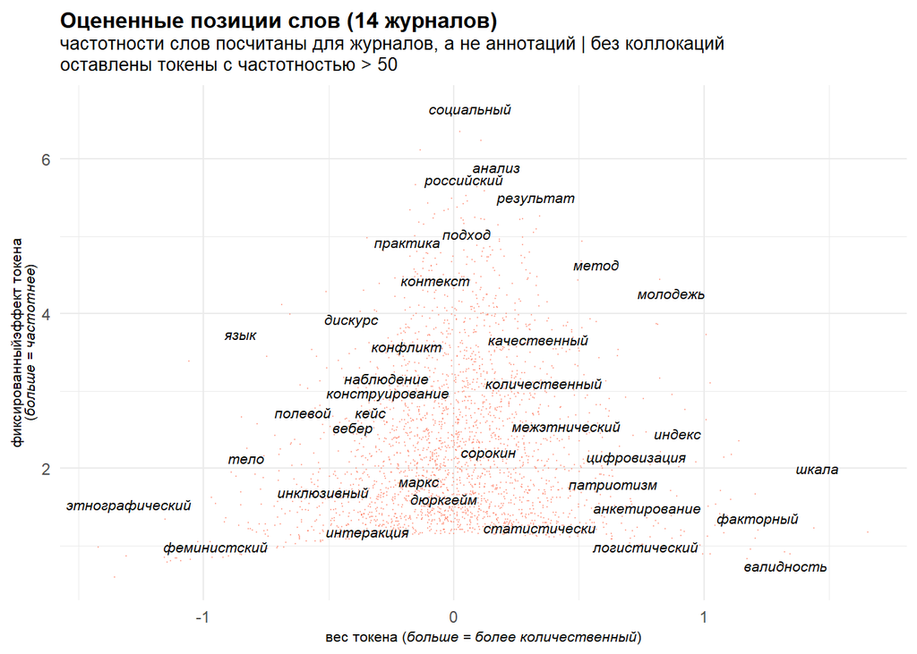

На графике выше наблюдения (слова) - это аргументы полученной модели. По оси x отложены веса (шкалированные значения): слова, одинаково часто встречающиеся во всех журнальных корпусах, распределены около 0 (“анализ”, “подход”, “результат”), полярные же значения занимают токены, характреные для журналов *“Laboratorium”* и *“Социология. 4М”* (см. пред. график). Токен “качественный” является более частотным, чем “количественный”, однако они занимают практически неотличимое положение на шкале x. Так, оба этих токена являются плохими индикаторами используемой в статье методологии; к такому же заключению приходят авторы оригинальной статьи, где модель применяется к англоязычным данным (Schwemmer & Wieczorek, 2020, p. 13).

Подписи даны лишь самым характерным токенам, так, чтобы полученное пространство было интерпретируемо. Левая часть спектра, вкключающая токены “этнографический”, “полевой”, “наблюдение” и “кейс” представляет качественный полюс. Примечательно, что к нему же тяготеет токен “вебер”: немецкий классик был автором проекта “понимающей социологии”, как раз связанной с качественной методологией. Говоря о темах исследований, расположенных в этом конце, стоит обратить внимание на токены “тело”, “интеракция”, “феминистский”, “конструирование”. Лексика на противоположном конце спектра обычна для количественных исследований: “шкала”, “индекс”, “валидность” и проч. Здесь тематическими токенами являются “цифровизация”, “патриотизм”, “молодежь”.

## **Результаты - 2: *correlated topic model***

Полученное в предыдущем блоке с помощью модели Wordfish решение имеет понятные ограничения. Во-первых, тяжело отделить эффект специфичной лексики полярных журналов от их тематической специфики. Может быть и так, что эти журналы действительно отличаются от всего остального корпуса, а количественная/качественная лексика в них - лишь одна из составляющих этой разницы, что приводит к искажению результатов. Следовательно, можно подвергнуть сомнению и полученное распределение журналов: конечно, *“Экономическую социологию”* тяжело назвать “качественным” журналом; скорее, речь идет о близости используемой в его аннотациях лексики (не только связанной с методами) к лексике *“Laboratorium”*. Во-вторых, финальное решение ограничено тем, что оно предлагает веса только для журналов, не позволяя оценивать отдельные статьи.

По этим причинам в качестве второго метода анализа аннотационного корпуса было использовано моделирование тем. Это большое семейство алгоритмов, также основанных на распределении частотностей слов по документам, производящее некоторое количество “тем” (т.е. групп слов, чье появление в тексте ассоциировано друг с другом) и оценку того, насколько каждая тема представлена в том или ином документе (DiMaggio et al., 2013, p. 577). Главным преимуществом этого метода заключается в том, что он позволяет анализировать большие объемы данных при относительно низкой вычислительной требовательности; преимущество по сравнению с использованной выше моделью Wordfish - в том, что моделирование тем производит не одну “тематическую” шкалу (континуум), но множество. Благодаря этому результаты в меньшей степени подвержены влиянию какого-либо набора документов с радикально отличающейся от прочих документов лексикой: здесь эти документы получат свою собственную “тему” (см. ниже на ассоциацию темы “демография” и *“Демографического обозрения”*). название и характеристику сгенерированным темам присваивает исследователь путем подробного изучения как слов, относящихся к той или иной теме, так и документов, в которых та или иная тема наиболее выражена.

Тексты аннотаций как данные для моделирования тем исторически были важны для развития всего семейства методов: ранний пример использования correlated topic model (CTM) был основан на корпусе аннотаций из журнала *“Science”* (Blei & Lafferty, 2007). Обычно моделирование тем используют для описания исследовательского поля и его динамики во времени; отдельным инструментальным назначением этих методов может служить определение теоретических теоретических пробелов (Westgate et al., 2015). Как правило, входящий корпус в такого рода исследованиях состоит не из дисциплинарной области, а из какой-либо ее части, поскольку так авторы могут проявить большую экспертность по теме и оценить качество получаемых решений (см. примеры про conservation science в Westgate et al., 2015; социальные движения в Lindstedt, N. C. 2019; лидерство в образовании в Wang et al. 2017). На это также влияет то, что естественное ограничение любого подхода к моделированию тем, - необходиомсть предоставить алгоритму конкретное число тем, которое следует извлечь из корпуса, - становится более критичным при работе с корпусами большого размера и/или большим количеством потенциальных тем. В отношении социологии целиком, тем не менее, ранее было предпринято несколько попыток сконструировать тематический ландшафт. Для этого, например, использовали аннотации статей из *“American Journal of Sociology”* за 1921-2016 годы (Giordan et al., 2018). В другой работе моделироавние тем в большом корпусе аннотаций социологических статей стало лишь первым шагом для оценки зависимости дисциплины от экономики (Daoud & Kohl, 2015).

При выборе конкретного метода для моделирования тем в собранном аннотационном корпусе я ориентировался на аргументацию, предложенную в исследовании “тем” в исследоавниях высшего образования (Daenekindt & Huisman., 2020). Наиболее распространенный метод моделирования тем - Latent Dirichlet Allocation (LDA), - предполагает независимость появления тем в документе друг от друга. Это серьезное допущение, влияющее на результаты: то, что на языке метода понимается под “темами”, в человеческих текстах редко независимо друг от друга. Скажем, тема “количественные методы” (со словами “регрессия”, “шкала” и т.д.) с куда большей вероятностью будет появляться вместе с темой “демография” (со словами “смертность”, “рождаемость”, “продолжительность”), чем с темой “гендерное неравенство” (слова “стереотип”, “неравенство”, “насилие” и проч.). Correlated topic model (CTM) ослабляет условие неезависимости между темами, допуская корреляцию между темами (Blei & Lafferty, 2007). Оригинальный алгоритм и его реализации требуют больших вычислительных мощностей, из-за чего для инициализации модели был использован спектральный метод, реализованный в пакете `stm` в R (Roberts et al. 2019).

Наконец, процесс предобработки текстов для моделирования тем несколько отличается от того, что был описан выше в отношении модели Wordfish. Поскольку результат не зависит от вкраплений нехарактерной для всего корпуса лексики, для анализа использовались все 18 журналов. Для большей надежности данных было решено ограничить период публикации статей с 2010 по 2022 годы. Далее, из данных были удалены все не-аннотационные части текстов (DOI, ключевые слова) и тексты, относящиеся к жанрам рецензий, обзоров, предваряющих выпуски редакторских обращений и т. п. Как и в прошлой секции, написание слов было нормализовано (“е” и “ё”). Программа mystem (Segalovich, 2003) была использована для лемматизации текстов и определения частей речи. Последнее было сделано для того, чтобы сделать корпус, состоящий исключительно из существительных, - это самая семантически насыщенная часть речи в языке, что позволяет повысить качество и интерпретируемость получаемых тем (Martin & Johnson, 2015). Наконец, из корпуса был удален 1% самых частотных слов (те, что в распределении слов, получаемом из результатов Wordfish, находились сверху: конституируемые ими темы (н. “лексика для начала аннотации” со словами “статья”, “феномен” и т. д.) являются инструментальными и не представляют интереса при описании дисциплинарного поля) и те слова, что встречаются менее чем в 1% всех документов (оба этих шага взяты из Daenekindt & Huisman., 2020). наконец, данные были приведены к формату матрицы термов-документов: она включала 9,217 документов (аннотаций) при 789 аргументов.

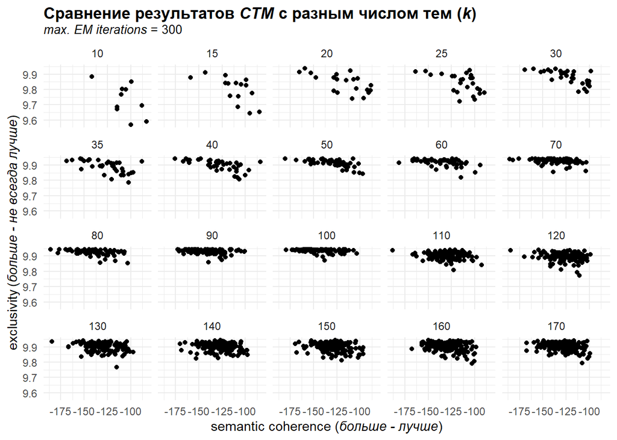

Необходимость выбора числа тем является одним из главных направлений критики любого подхода к моделированию тем и причиной, почему в уже неоднократно процитированной статье о методологическом разделении социологии авторы отказались от этой опции (Schwemmer & Wieczorek, 2020). Говоря более предметно, сложность состоит в том, что нет “правильного” числа тем, - число выбирается исходя из интерпретируемости результатов и исследовательских вопросов (DiMaggio et al. 2013). По этой причине процесс выбора параметра числа тем (k) неизбежно включает построение моделей с разным числом тем и сочетание автоматических и “ручных” методов их оценки. График выше показывает, как в моделях с разным параметром k изменяется распределение сгенерированных тем по осям семантической связности (устойчивость использования слов в теме; бОльшие значения сигнализируют об устойчивости модели/тем, низкие - о том, что модель/тема может состоять из подтем) и эксклюзивности (насколько складываемая в тему лексика отличительна от лексики других тем). Авторы прошлых исследований аннотаций социологических статей останавливались на значении k равном 15 (Daoud & Kohl, 2015; стоит заметить, что авторы не обсуждают это подробно, ссылаясь на то, что приблизительно такое же количество тем было в исследованиях Пола ДиМаджио и коллег (2013) и Нила Флигстина(2014), однако их исследования не касались анализа дисциплинарных полей) и 30 (Giordan et al., 2018; авторы оценивали модели от 2 до 50 тем и оценивали log-likelihood моделей. Важно, что авторы исследовали данные, покрывающие более чем вековую историю американской социологии, из-за чего некоторые темы остались в прошлом). Я остановился на значении k = 24: именно это число обеспечило сочетание высокой интерпретируемости (для этого использовался параметр FREX: средняя оценка порядка слова на основе его частотности (FRequency) и эксклюзивности (EXclusivity), взято из Daenekindt & Huisman, 2020) и создало своеобразный “запас” тем, которые оказались неинтерпретируемыми/смешанными (это обычное дело в моделировании тем: несоизмеримость того, как тексты видит человек и алгоритм проявляется в таких темах наиболее ясно).

Таблица ниже содержит наиболее характерные для тем слова (извлеченные не только с помощью метрики FREX) и присвоенные им названия. В тех случаях, когда характерной лексики было недостаточно для атрибутирования темы, были также рассмотрены документы, отличавшиеся их наибольшей представленностью.

| Номер темы | Присвоенные названия (% в корпусе) | Характерная лексика |
| --- | --- | --- |
| 1 | смешано (0.02%) | **PROB**: сми, медиа, элита, игра, информация, аудитория, карьера **FREX**: игра, сми, элита, аудитория, медиа, спорт, кампания **LIFT**: спорт, игра, кампания, имидж, сми, аудитория, элита **SCORE**:… |
| 2 | регионы (0.03%) | **PROB**: регион, область, житель, республика, территория, место, мобильность **FREX**: регион, республика, территория, местность, село, мобильность, житель **LIFT**: татарстан, республика, село, реги… |
| 3 | язык_дискурс (0.04%) | **PROB**: дискурс, язык, образ, текст, память, культура, народ **FREX**: язык, дискурс, текст, память, репрезентация, нарратив, народ **LIFT**: текст, репрезентация, дискурс, язык, нарратив, память, с… |
| 4 | методология_смешано (0.07%) | **PROB**: метод, решение, использование, технология, задача, применение, стратегия **FREX**: решение, метод, применение, технология, задача, использование, разработка **LIFT**: парадокс, алгоритм, инт… |
| 5 | потребление (0.02%) | **PROB**: услуга, потребление, стиль, продукт, потребитель, помощь, благо **FREX**: потребление, стиль, потребитель, продукт, питание, услуга, благо **LIFT**: питание, потребление, потребитель, стиль,… |
| 6 | безопасность (0.04%) | **PROB**: риск, ситуация, конфликт, бизнес, кризис, безопасность, поведение **FREX**: безопасность, бизнес, угроза, конфликт, коррупция, риск, кризис **LIFT**: коррупция, угроза, опасность, безопаснос… |
| 7 | демография (0.04%) | **PROB**: рост, период, число, причина, динамика, снижение, доля **FREX**: смертность, рост, рождаемость, снижение, сокращение, смерть, пандемия **LIFT**: смертность, продолжительность, смерть, перепи… |
| 8 | образование_школа (0.02%) | **PROB**: школа, учреждение, инвалидность, дом, барьер, социализация, поколение **FREX**: инвалидность, школа, учитель, учреждение, дом, детство, подросток **LIFT**: детство, учитель, инвалидность, шк… |
| 9 | методология_2_выборки (0.05%) | **PROB**: опрос, интервью, респондент, мнение, помощь, ответ, методика **FREX**: врач, методика, руководитель, респондент, опрос, ответ, интервью **LIFT**: интервьюер, врач, пациент, анкета, ошибка, р… |
| 10 | философия (0.08%) | **PROB**: идея, точка, зрение, интерпретация, философия, понятие, действие **FREX**: философия, идея, интерпретация, критика, аргумент, зрение, тезис **LIFT**: витгенштейн, философия, философ, учение,… |
| 11 | повседневность (0.07%) | **PROB**: мир, образ, объект, представление, смысл, реальность, основание **FREX**: мир, реальность, объект, смысл, граница, природа, свойство **LIFT**: истина, реальность, миф, прогресс, свойство, ми… |
| 12 | молодежь (0.05%) | **PROB**: ценность, молодежь, установка, идентичность, культура, россиянин, ориентация **FREX**: молодежь, ценность, установка, ориентация, россиянин, идентичность, сознание **LIFT**: патриотизм, моло… |
| 13 | гендерное_неравенство (0.02%) | **PROB**: женщина, мужчина, насилие, стереотип, война, равенство, пол **FREX**: женщина, насилие, мужчина, стереотип, равенство, война, гендер **LIFT**: насилие, женщина, равенство, мужчина, стереотип… |
| 14 | наука_университет (0.05%) | **PROB**: наука, студент, университет, вуз, проект, знание, ученый **FREX**: университет, вуз, наука, ученый, студент, преподаватель, дисциплина **LIFT**: кафедра, университет, преподаватель, вуз, уче… |
| 15 | соц_теория (0.07%) | **PROB**: концепция, внимание, понятие, направление, социолог, традиция, поле **FREX**: концепция, религия, концепт, социолог, традиция, вебер, проблематика **LIFT**: дюркгейм, вебер, модерн, религия,… |
| 16 | органы_власти (0.05%) | **PROB**: власть, право, гражданин, орган, контроль, управление, реализация **FREX**: орган, право, власть, защита, контроль, служба, инициатива **LIFT**: суд, орган, законодательство, защита, право, … |
| 17 | забота (0.02%) | **PROB**: семья, ребенок, родитель, забота, поддержка, мать, уход **FREX**: забота, ребенок, семья, мать, уход, отец, родительство **LIFT**: отец, забота, мать, родительство, уход, ребенок, семья **SC… |
| 18 | здоровье_благополучие (0.05%) | **PROB**: здоровье, положение, показатель, характеристика, неравенство, доход, возраст **FREX**: здоровье, удовлетворенность, доход, самочувствие, благополучие, показатель, положение **LIFT**: счастие… |
| 19 | взаимодействие (0.04%) | **PROB**: взаимодействие, сеть, участник, идентичность, коммуникация, сообщество, пользователь **FREX**: сеть, пользователь, участник, взаимодействие, эмоция, общность, коммуникация **LIFT**: эмоция, … |
| 20 | институциональное_доверие (0.03%) | **PROB**: институт, участие, доверие, капитал, активность, интернет, готовность **FREX**: доверие, интернет, цифровизация, институт, готовность, капитал, участие **LIFT**: доверие, недоверие, цифровиз… |
| 21 | миграция (0.04%) | **PROB**: город, сообщество, мигрант, пространство, миграция, интеграция, среда **FREX**: мигрант, город, миграция, интеграция, сообщество, горожанин, инфраструктура **LIFT**: мигрант, иммигрант, горо… |
| 22 | стратификация (0.04%) | **PROB**: труд, рынок, экономика, работник, класс, ресурс, производство **FREX**: труд, экономика, предприятие, рынок, собственность, работник, класс **LIFT**: собственность, труд, предприятие, оплата… |
| 23 | историческая_социология (0.06%) | **PROB**: движение, история, модернизация, событие, начало, революция, период **FREX**: движение, революция, модернизация, начало, ссср, конец, демократия **LIFT**: революция, движение, ссср, демократ… |
| 24 | семья (0.02%) | **PROB**: брак, возраст, траектория, переход, выбор, поведение, поколение **FREX**: брак, траектория, переход, союз, возраст, рождение, выбор **LIFT**: брак, траектория, партнер, союз, обследование, р… |

Ввиду того, что CTM представляет каждый документ как сочетание тем, можно оценить то, какие из тем чаще всего встречаются вместе. Для этого, следуя авторам исследования аннотаций в публикациях о высшем образовании (Daenekindt & Huisman, 2020), было применена иерархическая кластеризация данных формата документы-темы (9,205 документов при 24 темах). Композиционная природа матрицы термов-документов была учтена с помощью (1) трансформации матрицы с Aitchison composition scales и (2) ковариационной матрицы (Van den Boogaart & Tolosana-Delgado, 2013). Для измерения расстояния между документами был использован метод Варда (Ward). Результаты кластеризации представлены на дендрограмме ниже:

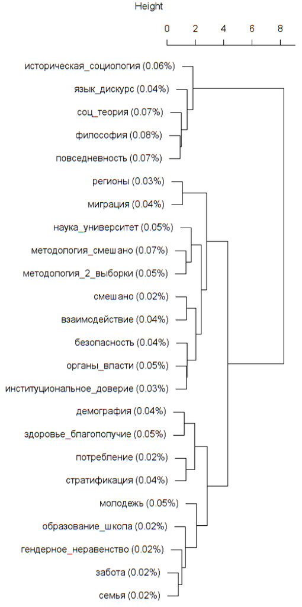

Другим стандартным методом анализа соотношения тем, произведенных с CTM, является представление тем в графе, построенном на основе корреляций между ними (Lafferty & Blei, 2005; Blei & Lafferty, 2007). Для представления данного набора тем были сохранены значимые корреляции > 0.03, прочие же были приравнены к 0.

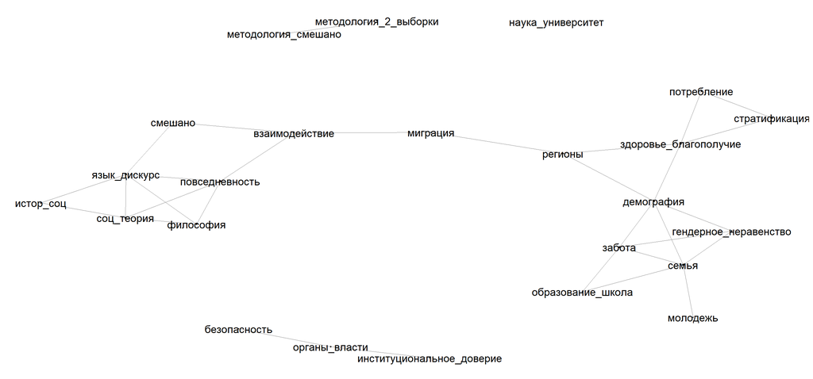

Получаемый таким образом “тематический” ландшафт дополняет результат кластеризации, приведенный выше. Кластер, связанный с государственными институтами, оказывается изолированным от прочих тем, как и “инструментальные” мотодологические темы и тема “наука_университет”. Крупнейший компонет, насчитывающий 18 тем, условно состоит из наблюдаемого ранее “теоретического” кластера (к которому присоединились темы “смешано” и “взаимодействие”); прочие темы, соединяющиеся с “теоретической” частью сети можно назвать “эмпирическими”. То, что эти две части причудливо связаны темой “миграции”, можно связать с тем, что тема “взаимодействия” содержит лексику, применяемую для описания миграционных процессов.

Кажется важным, что доли тем в аннотациях всех журналов, разбитых по годам, практически не изменились ни для одной темы. Самым критичным стало снижение доли темы “соц_теория” после 2012 года примерно на 3% (есть соблазн найти этому внешнее объяснение, связанное, например, с программой “5-100” и повышением публикационного давления на ученых, - кажется, что написать эмпирическую статью в хороший российский журнал должно быть проще, чем теоретическую, - однако это слишком сильный тезис, требующий более внимательной проверки):

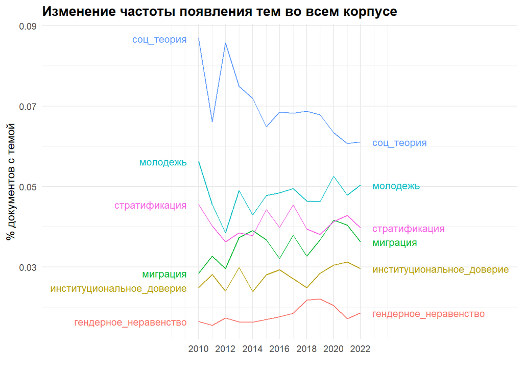

## **Размышления о результатах**

Полученные результаты описывают скорее не “разрывы” в российской социологии, а его тематический/методологический ландшафт, явленный в главных национальных дисциплинарных журналах. Финальная форма модели Wordfish указывает на то, что содержание статей все-таки можно задать с помощью оппозиции “количественного” и “качественного”, однако это решение (1) сделано исключительно для журналов, т.е. без взвешивания позиций отдельных аннотаций, (2) уступает в очевидности разделения результатам немецких ученых (Schwemmer & Wieczorek, 2020, p. 12), в работе которых ассоциация между исследовательскими темами и методологиями представлена более убедительно. Можно сравнить данное выше распределение термов с тем, что получили эти авторы:

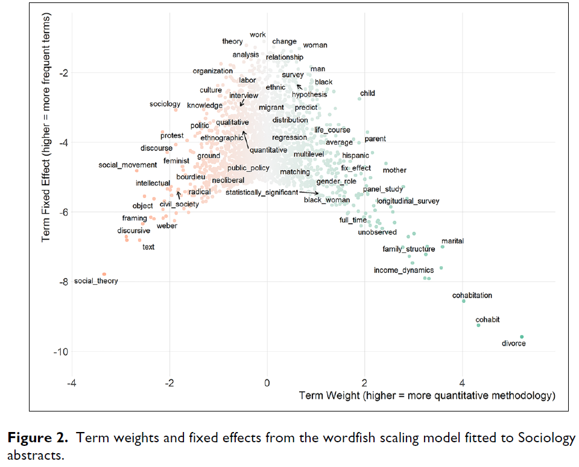

Если брать найденную этими авторами дисциплинарную структуру за образец, то можно предположить, что российская социология сильно отличается от “мировой”. В ней лишь с оговорками присутствует представленный на мировом уровне дебат “качественного” и “количественного”. Однако, т. к. весь этот аргумент построен на серии смелых предположений, - в том числе, что журнальные публиакции (тексты) представляют реальную науку (о том, что для науки куда важнее неявное знание, которое невозможно передать посредством текста, сказано у многих классиков социологии науки, н. у Гарри Коллинза, см. Collins, 1974), что аннотационные данные корректно передают содержание статей (кажется, что о структуре российских аннотаций, которые в начале 2000 годов еще не являлись обязательной частью публикаций в некоторых журналах, можно было бы написать отдельно), - скорее не позволяет сделать таких предположений. Возможным объяснением отличия является то, что сам процесс написания аннотации в российской дисциплине куда менее институирован, чем в “мировых” журналах. Как было отмечено, не у всех журналов аннотация вовсе являлась обязательным элементом текста еще совсем недавно. Показательно также и то, что многие аннотации не содержат относительно подробного описания использованной методологии, что необычно в сравнении с “мировыми” журналами.

Если гипотеза об институционализации практики написания аннотации верна, то еще любопытнее становятся результаты, полученные на ранней стадии этой работы. Тогда для знакомства с моделью Wordfish были собраны аннотации выпускных квалификационных работ, написанных на бакалаврских и магистерских программах по социологии в Высшей Школе Экономики (всего было собрано 2,510 текстов). Решение модели Wordfish, примененной к этим данным, дано ниже.

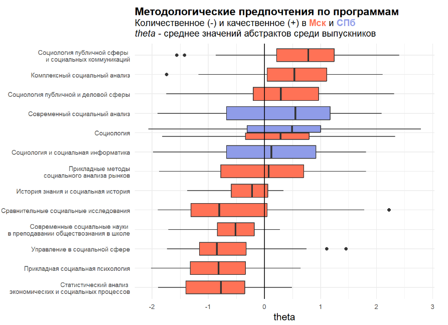

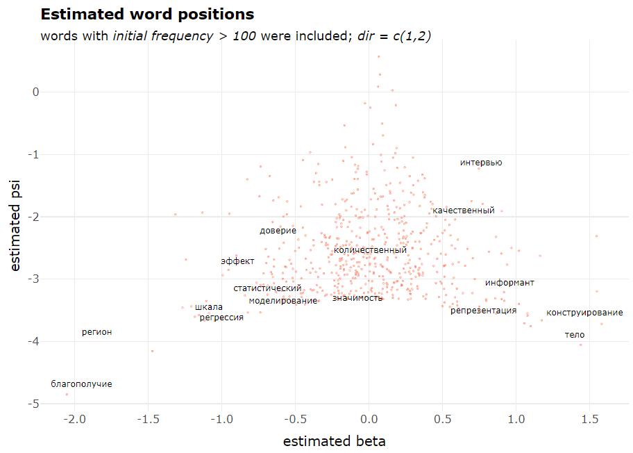

При подготовке своих работ студенты находятся под надзором научных руководителей (которые могут быть заинтересованы именно в “хорошей” аннотации, ведь она, например, появится на странице преподавателя на сайте университета, и станет своеобразным сигналом о его/ее научных интересах и качестве работ, написанных под его/ее руководством, - это сигнал как для других самостоятельных членов академии, н. журнальных редакций и потенциальных соавторов, так и для будущих студентов, находящихся в поиске наставника) и под своеобразным изоморфным давлением со стороны канонов оформления аннотаций в западных журналах (которым в “Вышке” отдается явное предпочтение при составлении учебных планов). Кажется, это приводит к тому, что студенческий (!) аннотационный корпус ориентированного на западную академию института оказывается более похож на картину, продемонстрированную немецкими авторами.

Полученные в результате моделирования тем представляют скорее дескриптивный интерес и, безусловно, требуют валидации от участников поля (н. аффилированных с журналами социологов, понимающих реальное содержание публикуемых статей). Сравнивать выбранное число тем и их состав с результатами прошлых исследованиях аннотаций социологических статей (Giordan et al., 2018; Daoud & Kohl, 2015) трудно, т. к. каждое исследование имело свой собственный текстовый корпус со всеми его уникальными особенностями. В случае данного исследования определенным препятствием в интерпретации результатов стало то, что один из журналов, *“Вестник ТГУ”*, посвящен не только социологии, и некоторые аргументы (лексика) из него удивительным образом пересекалась с лексикой из других тем, внося в них некоторый шум. Также важным ограничением моделирования тем на имеющемся корпусе является то, что, как утверждалось выше, написание аннотации в контексте российской социологии не является институированной практикой. При всем этом моделирование тем подтверждает пусть очевидную, но оппозицию между теоретическими и эмпирическими работами, и вскрывает некоторые неочевидные тематические кластеры (н. тот, что связан с изучением государственных институтов).

### **p.s. что еще хочется успеть**

- построить более “корректную” финальную модель Wordfish: сейчас она выполнена без учета коллокаций;
- **привести в порядок метаданные статей и сопоставить полученные темы с, например, авторскими аффилиациями и числом соавторов;**
- еще раз посмотреть на CTM с другими значениями k: вероятно, можно получить более интерпретируемое решение, которое я упустил;
- **собрать аннотации для пропущенных годов - в первую очередь, это относится к *“СоцИсу”* за 2010-2013 годы.**

## **Библиография**

Blei, D. M., & Lafferty, J. D. (2007). A correlated topic model of science.

Collins, H. M. (1974). The TEA set: Tacit knowledge and scientific networks. Science studies, 4(2), 165-185.

DiMaggio, P., Nag, M., & Blei, D. (2013). Exploiting affinities between topic modeling and the sociological perspective on culture: Application to newspaper coverage of US government arts funding. Poetics, 41(6), 570-606.

Daenekindt, S., & Huisman, J. (2020). Mapping the scattered field of research on higher education. A correlated topic model of 17,000 articles, 1991–2018. Higher Education, 80(3), 571-587.

Daoud, A., & Kohl, S. (2015). Is there a New Economic Sociology Effect? A Topic Model on the Economic Orientation of Sociology, 1890 to 2014.

Giordan, G., Saint-Blancat, C., & Sbalchiero, S. (2018). Exploring the history of American sociology through topic modelling. Tracing the Life Cycle of Ideas in the Humanities and Social Sciences, 45-64.

Lafferty, J., & Blei, D. (2005). Correlated topic models. Advances in neural information processing systems, 18.

Lindstedt, N. C. (2019). Structural topic modeling for social scientists: A brief case study with social movement studies literature, 2005–2017. Social Currents, 6(4), 307-318.

Martin, F., & Johnson, M. (2015, December). More efficient topic modelling through a noun only approach. In Proceedings of the Australasian Language Technology Association Workshop 2015 (pp. 111-115).

Roberts, M. E., Stewart, B. M., & Tingley, D. (2019). Stm: An R package for structural topic models. Journal of Statistical Software, 91, 1-40.

Schwemmer, C., & Wieczorek, O. (2020). The methodological divide of sociology: Evidence from two decades of journal publications. Sociology, 54(1), 3-21.

Segalovich, I. (2003). A fast morphological algorithm with unknown word guessing induced by a dictionary for a web search engine. MLMTA, 2003, 273.

Slapin, J. B., & Proksch, S. O. (2008). A scaling model for estimating time‐series party positions from texts. American Journal of Political Science, 52(3), 705-722.

Van den Boogaart, K. G., & Tolosana-Delgado, R. (2013). Analyzing compositional data with R (Vol. 122, pp. 1-200). Berlin: Springer.

Wang, Y., Bowers, A. J., & Fikis, D. J. (2017). Automated text data mining analysis of five decades of educational leadership research literature: Probabilistic topic modeling of EAQ articles from 1965 to 2014. Educational administration quarterly, 53(2), 289-323.

Westgate, M. J., Barton, P. S., Pierson, J. C., & Lindenmayer, D. B. (2015). Text analysis tools for identification of emerging topics and research gaps in conservation science. Conservation Biology, 29(6), 1606-1614.